# Modelos Mistos

Análise de dados com modelos lineares em R

Nicholas A. C. Marino

github.com/nacmarino/metodosR

## Modelos mistos

- Por vezes nosso desenho experimental incorpora elementos que devemos considerar nos modelos:
  - Blocos espaciais e/ou temporais
  - Medidas repetidas nos mesmos indivíduos
  - Observações aninhadas dentro de grupos
  - Auto-correlação espacial ou temporal
  - Variância não homogênea entre grupos
- Para tanto, utilizamos modelos mistos, que incoporam as variáveis preditoras fixas (do nosso interesse) e também as variáveis preditoras aleatórias (no geral, não são de nosso interesse) - por isso são chamado de *modelos mistos*.

## Modelos mistos

- Podemos incorporar uma variável aleatória como um:
  - Intercepto: os níveis do fator modificam os valores médios da variável resposta (intercepto da regressão difere, slopes podem ser semelhantes)
  - Slope: os níveis do fator modificam a relação da variável resposta com as variáveis preditoras (slopes podem variar de acordo com os níveis)

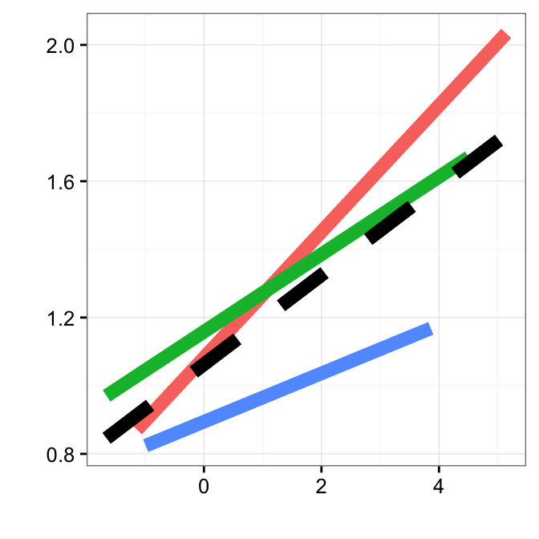

## Modelos mistos | Intercepto aleatório

- Por exemplo, um modelo linear somente com várias fixas:

*y* = $\beta$<sub>0</sub> + $\beta$<sub>1</sub> * *x<sub>1</sub>* + $\epsilon$

- Adicionando uma variável aleatória, como um intercepto aleatório no modelo:

*y* = ($\beta$<sub>0</sub> + **$\omega$<sub>i</sub>**) + $\beta$<sub>1</sub> * *x<sub>1</sub>* + ($\epsilon$ + **$\epsilon$<sub>i</sub>**)

## Modelos mistos | Slope aleatório

- Por exemplo, um modelo linear somente com várias fixas:

*y* = $\beta$<sub>0</sub> + $\beta$<sub>1</sub> * *x<sub>1</sub>* + $\epsilon$

- Adicionando uma variável aleatória, como um slope aleatório no modelo:

*y* = $\beta$<sub>0</sub> + ($\beta$<sub>1</sub> + **$\omega$<sub>i</sub>**) * *x<sub>1</sub>* + ($\epsilon$ + **$\epsilon$<sub>i</sub>**)

## Modelos lineares mistos

- Os parâmetros dos modelos lineares mistos são determinados através de dois métodos:
  - Maximum Likelihood (ML)
  - Restricted Maximum Likelihood (REML)
- REML é o método padrão para o cálculo da estimativa dos parâmetros.
- O REML é mais robusto do que o ML, pois corrige as estimativas dos parâmetros através da correção pelo número de graus de liberdade do modelo.
- Como consequência, normalmente utilizamos ML para fazer a seleção de modelos e o REML para validar o modelo e determinar a estimativa final dos parâmetros.

## Modelos mistos

- No R, modelos mistos são implementados através dos pacotes `nlme` e `lme4`:
  - `nlme::lme`: modelos lineares mistos, com boas funcionalidades para inclusão de estruturas de autocorrelação e de diferenças na variância entre grupos (`correlation` e `weights`)
  - `lme4::lmer`: modelos lineares mistos (distribuição normal)
  - `lme4::glmer`: modelos lineares generalizados mistos (**danger zone**), implementa a funcionalidade das GLMs nos modelos mistos - teoria ainda em desenvolvido (tende à instabilidade e pode ser temperamental)
- Todas as boas práticas de seleção e validação de modelos que aprendemos para a `glm` valem para os modelos mistos.

## Modelos lineares mistos

- Vamos implementar um modelo misto no conjunto de dados que estamos trabalhando.
- Vamos utilizar o tipo de ilha como uma variável aleatória: a relação espécies-área é válida apenas para o subconjunto de dados que temos OU a relação é existente apesar da heterogeneidade entre tipos de ilhas?

```r
ilhas <- read.table(file = "../model_selection/dados/ilhas.txt", header = TRUE)
library(lme4)
modelo1 <- lmer(log10(riqueza) ~ arquipelago + log10(area) + (1|ilha), data = ilhas)
```

- No `nlme` usaríamos: `lme(log10(riqueza) ~ log10(area) + arquipelago, random = ~ 1|ilha, data = ilhas)`

## Modelos lineares mistos

```
## Linear mixed model fit by REML ['lmerMod']
## Formula: log10(riqueza) ~ arquipelago + log10(area) + (1 | ilha)
##    Data: ilhas
##
## REML criterion at convergence: -103.8
##
## Scaled residuals:
##     Min      1Q  Median      3Q     Max
## -2.3691 -0.6197 -0.1095  0.5453  3.4730
##
## Random effects:
##  Groups   Name        Variance Std.Dev.
##  ilha     (Intercept) 0.11154  0.3340
##  Residual             0.01141  0.1068
## Number of obs: 80, groups:  ilha, 2
##
## Fixed effects:
##                     Estimate Std. Error t value
## (Intercept)         1.235561   0.237752   5.197
## arquipelagomedio   -0.187472   0.030561  -6.134
## arquipelagopequeno -0.391119   0.033893 -11.540
## log10(area)         0.145131   0.008791  16.509
##
## Correlation of Fixed Effects:
##             (Intr) arqplgm arqplgp
## arquipelgmd -0.087
## arquiplgpqn -0.074  0.573
## log10(area) -0.053  0.040   0.040
```

## Modelos lineares mistos | Seleção e Diagnóstico de Modelos

- A seleção e o diagnóstico dos modelos seguem as mesmas recomendações apresentadas anteriormente;
- Você também pode calcular o valor de r<sup>2</sup> com os modelos mistos.
  - r<sup>2</sup> marginal (**R2m**): somente as variáveis fixas
  - r<sup>2</sup> condicional (**R2c**): variáveis fixas + variáveis aleatórias

```r
library(MuMIn)
r.squaredGLMM(modelo1)
```

```
##       R2m       R2c
## 0.3344247 0.9382509
```

## Modelos lineares mistos | Seleção e Diagnóstico de Modelos

- Você pode comparar os modelos com e sem as variáveis aleatórias?
  - Poder você pode, mas não deveria (afinal, isso não faz parte do seu desenho experimental?)
  - Testes de verossimilhança entre modelos mistos e os modelos normais não são comparáveis
- O pacote `lmerTest` implementa algumas funcionalidades para trabalhar LMMs.
  - `step`: seleção de modelos.
  - `rand`: testes de verossimilhança para as variáveis aleatórias.
  - `difflsmeans`: pós-teste.

## Modelos lineares mistos

- Vamos olhar o modelo com calma: o pacote `broom`, função `tidy`.
- Podemos ver que a inclusão do intercepto aleatório adiciona dois parâmetros extras:
  - o intercepto para o tipo de ilha
  - um valor de resíduo (erro) para cada observação em cada tipo de ilha
- Note, no entanto, que não existe estimativa de erro e nem uma estatística para estes dois parâmetros - **qual a consequência?**

```r
broom::tidy(modelo1)
```

```
##                      term   estimate   std.error  statistic    group
## 1             (Intercept)  1.2355612 0.237752310   5.196842    fixed
## 2        arquipelagomedio -0.1874719 0.030560828  -6.134385    fixed
## 3      arquipelagopequeno -0.3911192 0.033893417 -11.539680    fixed
## 4             log10(area)  0.1451308 0.008790995  16.509026    fixed
## 5     sd_(Intercept).ilha  0.3339808          NA         NA     ilha
## 6 sd_Observation.Residual  0.1068024          NA         NA Residual
```

## Modelos lineares mistos | Significância dos Termos no Modelo

```r
library(car)
Anova(modelo1, type = "II", test.statistic = "F") # certo?
```

```
## Analysis of Deviance Table (Type II Wald F tests with Kenward-Roger df)
##
## Response: log10(riqueza)
##                   F Df Df.res    Pr(>F)
## arquipelago  66.753  2 75.020 < 2.2e-16 ***
## log10(area) 272.520  1 75.004 < 2.2e-16 ***
## ---
## Signif. codes:  0 '***' 0.001 '**' 0.01 '*' 0.05 '.' 0.1 ' ' 1
```

## Modelos lineares mistos | Significância dos Termos no Modelo

- O criador do pacote `lme4` faz algumas sugestões (do pior para o melhor): [http://glmm.wikidot.com/faq]
  1. Wald chi-square testes (car::Anova)
  2. Likelihood ratio test (via anova ou drop1)
  3. Conditional F-tests
  4. Para LMMs apenas, conditional F-tests com correção para os graus de liberdade (Kenward-Roger ou Satterthwaite)
  5. Testes de aleatorização
- Para a opção 4: `lmerTest::anova`

```r
lmerTest::anova(object = modelo1, type = 2, ddf = "Satterthwaite")
```

```
## Analysis of Variance Table
##             Df Sum Sq Mean Sq F value
## arquipelago  2 1.6994  0.8497  74.491
## log10(area)  1 3.1089  3.1089 272.548
```

## Modelos generalizados lineares mistos | Panorama geral

- Os modelos mistos também possuem uma versão para incoporar outras distribuições estatísticas no seu modelo: GLMMs.
- Teoria ainda em desenvolvimento e não são tão estáveis, ainda (`mas veja a opção do pacote`glmmADMB`).
- De toda forma, você pode implementar ele - e todas as recomendações para os outros modelos também valem aqui.
- Para calcular a **overdispersion** existe uma função, fornecida pelo próprio criador do pacote `lme4`.

```r
source("../../R functions/overdisp.R")
```

## Modelos generalizados lineares mistos | Panorama geral

```r
modelo2 <- glmer(mamiferos ~ arquipelago + log10(area) + (1|ilha), data = ilhas, family = poisson())
r.squaredGLMM(modelo2)
```

```
##       R2m       R2c
## 0.2044959 0.6874713
```

```r
overdisp_fun(modelo2)
```

```
##      chisq      ratio        rdf          p
##  8.4215724  0.1122876 75.0000000  1.0000000
```

## Modelos generalizados lineares mistos | Panorama geral

```r
summary(modelo2)
```

```
## Generalized linear mixed model fit by maximum likelihood (Laplace
##   Approximation) [glmerMod]
##  Family: poisson  ( log )
## Formula: mamiferos ~ arquipelago + log10(area) + (1 | ilha)
##    Data: ilhas
##
##      AIC      BIC   logLik deviance df.resid
##    311.8    323.7   -150.9    301.8       75
##
## Scaled residuals:
##      Min       1Q   Median       3Q      Max
## -1.24728 -0.16659 -0.01427  0.20097  0.68694
##
## Random effects:
##  Groups Name        Variance Std.Dev.
##  ilha   (Intercept) 0.2624   0.5123
## Number of obs: 80, groups:  ilha, 2
##
## Fixed effects:
##                    Estimate Std. Error z value Pr(>|z|)
## (Intercept)         1.36059    0.38042   3.577 0.000348 ***
## arquipelagomedio   -0.01447    0.11775  -0.123 0.902202
## arquipelagopequeno  0.05327    0.13470   0.395 0.692518
## log10(area)         0.24120    0.03361   7.175 7.21e-13 ***
## ---
## Signif. codes:  0 '***' 0.001 '**' 0.01 '*' 0.05 '.' 0.1 ' ' 1
##
## Correlation of Fixed Effects:
##             (Intr) arqplgm arqplgp
## arquipelgmd -0.210
## arquiplgpqn -0.198  0.606
## log10(area) -0.171  0.029   0.106
```

## Considerações finais

- Modelos mistos te permitem incorporar algumas especificidades do seu desenho experimental/amostral no modelo - inclusive algumas que envolvem a violação de pressupostos estatísticos.
- As mesmas recomendações que valem para a seleção e diagnóstico de modelos para `lm` e `glm` valem para os modelos mistos (`nlme`, `lmer` e `glmer`).
- Tanto o `lme` quanto o `lmer` implementam modelos lineares mistos, mas a forma como fazem isso difere um pouco - qual usar?
  - O que se adequar melhor ao seu desenho experimental/amostral
  - Lembrando que o `lme` permite a incoporação de diferenças na variância entre os níveis de fatores e de autocorrelação
- O `lme4` também implementa as GLMMs (`glmer`), seguindo a mesma lógica das GLMs - mas cuidado ao usar estes modelos, pois eles combinam a complexidade das GLMs com as dos modelos mistos (e ainda estão em fase de desenvolvimento).